# Question

Let quadratic function $f$ be defined below:

$$f(x)~=~x^{2}-{4}x-{4}$$

When curve $y=f(x)$ is graphed, we see two $x$-intercepts at $(x_1,0)$ and $(x_2,0)$.

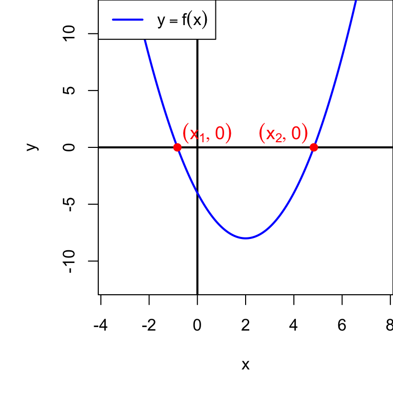

In exact form, those $x$ intercepts can be expressed as $h\pm p\sqrt{q}$.

$$x_1=h-p\sqrt{q}$$
$$x_2=h+p\sqrt{q}$$

Find the values of $h$, $p$, and $q$.

$h=$ ##ANSWER1##

$p=$ ##ANSWER2##

$q=$ ##ANSWER3##

## Answerlist

- -10
- -9
- -8
- -7
- -6
- -5
- -4
- -3
- -2
- -1
- 0
- 1
- 2
- 3
- 4
- 5
- 6
- 7
- 8
- 9
- 10
- 2
- 3
- 4
- 5
- 6
- 7
- 8
- 9
- 10
- 2
- 3
- 4
- 5
- 6
- 7
- 8
- 9
- 10

# Solution

The $x$ intercepts occur when either $x_1$ or $x_2$ satisfies $f(x)=0$.

$$x^{2}-{4}x-{4}=0$$

Identify the coefficients.

$$a=1$$
$$b=-4$$
$$c=-4$$

Plug numbers into the quadratic formula!

$$x =
\frac{-(-4)\pm\sqrt{(-4)^2-4(1)(-4)}}{2(1)}$$

Simplify.

$$x = \frac{4 \pm
\sqrt{16-(-16)}}{2}$$

Simplify.

$$x = \frac{4 \pm
\sqrt{32}}{2}$$

Use prime factorization.

$$x = \frac{4 \pm
\sqrt{2\cdot2\cdot2\cdot2\cdot2}}{2}$$

Isolate the twin factors.

$$x = \frac{4 \pm
\sqrt{2\cdot2\cdot2\cdot2}\cdot \sqrt{2}}{2}$$

Simplify the square root of the square.

$$x = \frac{4 \pm 2\cdot2\cdot
\sqrt{2}}{2}$$

Simplify the integer products.

$$x = \frac{4 \pm 4\cdot
\sqrt{2}}{2}$$

Split the fraction.

$$x = \frac{4}{2} \pm \frac{4\cdot
\sqrt{2}}{2}$$

Both numerators contain a factor of 2.

$$x = 2 \pm 2\sqrt{2}$$

So, $h=2$ and $p=2$ and $q=2$.

I should mention this means we could now write the function in **factored form**.

$$f(x)~=~\left[x-(2-2\sqrt{2})\right]\cdot\left[x-(2+2\sqrt{2})\right]$$

# Meta-information

extype: cloze exclozetype: schoice|schoice|schoice exsolution: 000000000000100000000|100000000|100000000 exname: et_qf_radical_solns